# Movie databse QM project

Nguyen Manh Luu 2.Vo Thi Ha Giang 3. Michael Seyram Morkly

January 4, 2017

## PART 1: EDA

## Load the data and rename it

```r
movie_metadata <- read.csv("C:/Users/Luu/Desktop/MIM/QM/data/movie_metadata.csv", header=TRUE, na.strings = c("NA",""))
```

```r
movie<-movie_metadata
```

## Look at the structure of the dataset and transform to data.table for easy handling, load necessary packages

```r
str(movie)
```

```
## 'data.frame':    5043 obs. of  28 variables:
##  $ color                    : Factor w/ 2 levels " Black and White",..: 2 2 2 2 NA 2 2 2 2 2 ...
##  $ director_name            : Factor w/ 2398 levels "A. Raven Cruz",..: 928 800 2026 379 605 108 2029 1651 1227 553 ...
##  $ num_critic_for_reviews   : int  723 302 602 813 NA 462 392 324 635 375 ...
##  $ duration                 : int  178 169 148 164 NA 132 156 100 141 153 ...
##  $ director_facebook_likes  : int  0 563 0 22000 131 475 0 15 0 282 ...
##  $ actor_3_facebook_likes   : int  855 1000 161 23000 NA 530 4000 284 19000 10000 ...
##  $ actor_2_name             : Factor w/ 3032 levels "50 Cent","A. Michael Baldwin",..: 1407 2217 2488 533 2432 2548 1227 800 2439 652 ...
##  $ actor_1_facebook_likes   : int  1000 40000 11000 27000 131 640 24000 799 26000 25000 ...
##  $ gross                    : int  760505847 309404152 200074175 448130642 NA 73058679 336530303 200807262 458991599 301956980 ...
##  $ genres                   : Factor w/ 914 levels "Action","Action|Adventure",..: 107 101 128 288 754 126 120 308 126 447 ...
##  $ actor_1_name             : Factor w/ 2097 levels "50 Cent","A.J. Buckley",..: 304 982 354 1967 527 442 786 222 337 34 ...
##  $ movie_title              : Factor w/ 4917 levels "#HorrorÂ ","[Rec] 2Â ",..: 398 2731 3279 3707 3332 1961 3289 3459 399 1631 ...
##  $ num_voted_users          : int  886204 471220 275868 1144337 8 212204 383056 294810 462669 321795 ...
##  $ cast_total_facebook_likes: int  4834 48350 11700 106759 143 1873 46055 2036 92000 58753 ...
##  $ actor_3_name             : Factor w/ 3521 levels "50 Cent","A.J. Buckley",..: 3441 1394 3133 1770 NA 2713 1969 2162 3017 2940 ...
##  $ facenumber_in_poster     : int  0 0 1 0 0 1 0 1 4 3 ...
##  $ plot_keywords            : Factor w/ 4760 levels "10 year old|dog|florida|girl|supermarket",..: 1319 4282 2075 3483 NA 650 4744 28 1141 2004 ...
##  $ movie_imdb_link          : Factor w/ 4919 levels "http://www.imdb.com/title/tt0006864/?ref_=fn_tt_tt_1",..: 2965 2721 4533 3756 4918 2476 2526 2458 4546 2551 ...
##  $ num_user_for_reviews     : int  3054 1238 994 2701 NA 738 1902 387 1117 973 ...
##  $ language                 : Factor w/ 47 levels "Aboriginal","Arabic",..: 12 12 12 12 NA 12 12 12 12 12 ...
##  $ country                  : Factor w/ 65 levels "Afghanistan",..: 64 64 62 64 NA 64 64 64 64 62 ...
##  $ content_rating           : Factor w/ 18 levels "Approved","G",..: 9 9 9 9 NA 9 9 8 9 8 ...
##  $ budget                   : num  2.37e+08 3.00e+08 2.45e+08 2.50e+08 NA ...
##  $ title_year               : int  2009 2007 2015 2012 NA 2012 2007 2010 2015 2009 ...
##  $ actor_2_facebook_likes   : int  936 5000 393 23000 12 632 11000 553 21000 11000 ...
##  $ imdb_score               : num  7.9 7.1 6.8 8.5 7.1 6.6 6.2 7.8 7.5 7.5 ...
##  $ aspect_ratio             : num  1.78 2.35 2.35 2.35 NA 2.35 2.35 1.85 2.35 2.35 ...
##  $ movie_facebook_likes     : int  33000 0 85000 164000 0 24000 0 29000 118000 10000 ...
```

```r
library(data.table)
```

```r
movie=as.data.table(movie)
library(ggplot2)
library(corrplot)
library(reshape2)
```

## 1. Movies of each country contributed to the dataset

```r
sort(table(movie$country))
```

```
##
##          Afghanistan                Aruba              Bahamas
##                    1                    1                    1
##             Bulgaria             Cambodia             Cameroon
##                    1                    1                    1
##                Chile             Colombia   Dominican Republic
##                    1                    1                    1
##                Egypt              Finland              Georgia
##                    1                    1                    1
##            Indonesia                Kenya           Kyrgyzstan
##                    1                    1                    1
##                Libya             New Line              Nigeria
##                    1                    1                    1
##        Official site             Pakistan               Panama
##                    1                    1                    1
##                 Peru          Philippines             Slovakia
##                    1                    1                    1
##             Slovenia         Soviet Union               Turkey
##                    1                    1                    1
## United Arab Emirates               Greece              Hungary
##                    1                    2                    2
##               Taiwan       Czech Republic              Iceland
##                    2                    3                    3
##          Switzerland         West Germany            Argentina
##                    3                    3                    4
##              Belgium                 Iran               Israel
##                    4                    4                    4
##              Romania          Netherlands               Poland
##                    4                    5                    5
##             Thailand               Sweden               Brazil
##                    5                    6                    8
##               Norway         South Africa              Denmark
##                    8                    8                   11
##               Russia              Ireland          South Korea
##                   11                   12                   14
##          New Zealand            Hong Kong               Mexico
##                   15                   17                   17
##                Italy                Japan                China
##                   23                   23                   30
##                Spain                India            Australia
##                   33                   34                   55
##              Germany               Canada               France
##                   97                  126                  154
##                   UK                  USA
##                  448                 3807
```

```r
cumsum(sort(table(movie$country)))
```

```
##          Afghanistan                Aruba              Bahamas
##                    1                    2                    3
##             Bulgaria             Cambodia             Cameroon
##                    4                    5                    6
##                Chile             Colombia   Dominican Republic
##                    7                    8                    9
##                Egypt              Finland              Georgia
##                   10                   11                   12
##            Indonesia                Kenya           Kyrgyzstan
##                   13                   14                   15
##                Libya             New Line              Nigeria
##                   16                   17                   18
##        Official site             Pakistan               Panama
##                   19                   20                   21
##                 Peru          Philippines             Slovakia
##                   22                   23                   24
##             Slovenia         Soviet Union               Turkey
##                   25                   26                   27
## United Arab Emirates               Greece              Hungary
##                   28                   30                   32
##               Taiwan       Czech Republic              Iceland
##                   34                   37                   40
##          Switzerland         West Germany            Argentina
##                   43                   46                   50
##              Belgium                 Iran               Israel
##                   54                   58                   62
##              Romania          Netherlands               Poland
##                   66                   71                   76
##             Thailand               Sweden               Brazil
##                   81                   87                   95
##               Norway         South Africa              Denmark
##                  103                  111                  122
##               Russia              Ireland          South Korea
##                  133                  145                  159
##          New Zealand            Hong Kong               Mexico
##                  174                  191                  208
##                Italy                Japan                China
##                  231                  254                  284
##                Spain                India            Australia
##                  317                  351                  406
##              Germany               Canada               France
##                  503                  629                  783
##                   UK                  USA
##                 1231                 5038
```

## 2. The change of movie number thoughout the year

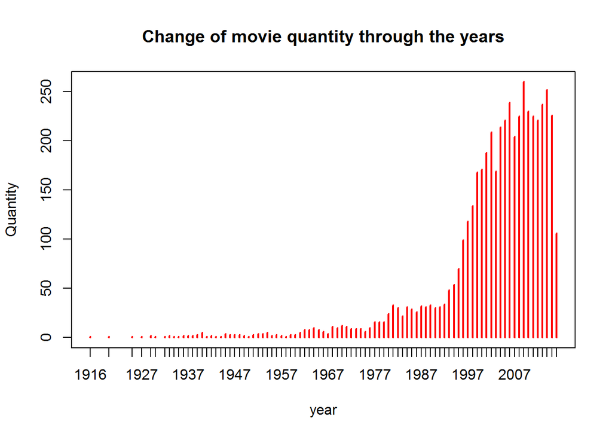

```r
plot(table(movie$title_year), col = "red", main = "Change of movie quantity through the years", xlab="year", ylab="Quantity")
```

## 3.Top 5 directors with most number of movies

```r
top5.director=head(sort(table(movie$director_name, useNA = "no"), decreasing=TRUE), n=5)
top5.director
```

```
##
## Steven Spielberg      Woody Allen   Clint Eastwood  Martin Scorsese
##               26               22               20               20
##     Ridley Scott
##               17
```

## 4. Movie with highest and lowest IMDB score

```r
movie.naomit=na.omit(movie)
movie.naomit[which.max(movie.naomit$imdb_score),list(director_name,gross,genres,movie_title,language, country,content_rating, title_year, budget, imdb_score)]
```

```
##     director_name    gross      genres                movie_title language
## 1: Frank Darabont 28341469 Crime|Drama The Shawshank RedemptionÂ   English
##    country content_rating title_year  budget imdb_score
## 1:     USA              R       1994 2.5e+07        9.3
```

```r
movie.naomit[which.min(movie.naomit$imdb_score),list(director_name,gross,genres,movie_title,language, country,content_rating, title_year, budget, imdb_score)]
```

```
##    director_name    gross            genres
## 1:    Jon M. Chu 73000942 Documentary|Music
##                         movie_title language country content_rating
## 1: Justin Bieber: Never Say NeverÂ   English     USA              G
##    title_year  budget imdb_score
## 1:       2011 1.3e+07        1.6
```

```r
summary(movie$imdb_score)
```

```
##    Min. 1st Qu.  Median    Mean 3rd Qu.    Max.
##   1.600   5.800   6.600   6.442   7.200   9.500
```

## 5.Most popular actor and their mean IMDB scores

```r
actor_max<- melt(table(movie$actor_1_name))
colnames(actor_max)=c("Actor name","Frequency")
actor_max[which.max(actor_max$Frequency),]
```

```
##          Actor name Frequency
## 1671 Robert De Niro        49
```

## Actor and mean imdb score

```r
meanimdb=tapply(movie$imdb_score, movie$actor_1_name, FUN=mean,na.rm=TRUE)
b=table(movie$actor_1_name)
c=cbind(meanimdb,b)
d=c[c[,2]>5,]
e=d[order(d[,1],decreasing=TRUE),]
e=as.data.frame(e)
e$actor.name=rownames(e)
e1=e[1:20,]
e1
```

```
##                        meanimdb  b             actor.name
## Leonardo DiCaprio      7.495238 21      Leonardo DiCaprio
## Roy Scheider           7.466667  6           Roy Scheider
## Tom Hanks              7.425000 24              Tom Hanks
## Clint Eastwood         7.337500 16         Clint Eastwood
## Madeline Kahn          7.333333  6          Madeline Kahn
## Tom Hardy              7.309091 11              Tom Hardy
## Alan Rickman           7.287500  8           Alan Rickman
## Benedict Cumberbatch   7.285714  7   Benedict Cumberbatch
## Philip Seymour Hoffman 7.240000 20 Philip Seymour Hoffman
## Toby Jones             7.216667  6             Toby Jones
## Minnie Driver          7.214286  7          Minnie Driver
## Christian Bale         7.200000 23         Christian Bale
## Harrison Ford          7.159259 27          Harrison Ford
## Kevin Spacey           7.150000 22           Kevin Spacey
## Denzel Washington      7.083333 30      Denzel Washington
## Brad Pitt              7.077778 18              Brad Pitt
## Dominic Cooper         7.071429  7         Dominic Cooper
## Jennifer Lawrence      7.046667 15      Jennifer Lawrence
## Holly Hunter           7.044444  9           Holly Hunter
## Robert Duvall          7.044444  9          Robert Duvall
```

## Draw the chart

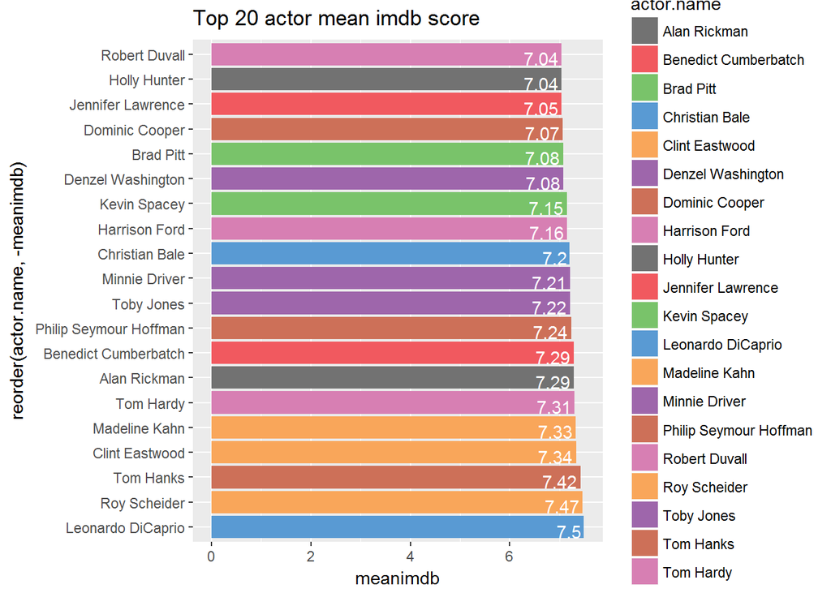

```r
colours=c("#727272", "#f1595f", "#79c36a", "#599ad3", "#f9a65a", "#9e66ab", "#cd7058", "#d77fb3","#727272", "#f1595f", "#79c36a", "#599ad3", "#f9a65a", "#9e66ab", "#cd7058", "#d77fb3","#f9a65a", "#9e66ab", "#cd7058", "#d77fb3")
ggplot(e1, aes(x=reorder(actor.name,-meanimdb),y=meanimdb, fill=actor.name))+geom_bar(stat="identity")+coord_flip()+scale_fill_manual(values=colours)+ geom_text(aes(label=round(meanimdb,2)), vjust=0.8, hjust=1.1, colour="white") + ggtitle("Top 20 actor mean imdb score")
```

##6. Information about budget

```r
summary(movie$budget)
```

```
##      Min.   1st Qu.    Median      Mean   3rd Qu.      Max.      NA's
## 2.180e+02 6.000e+06 2.000e+07 3.975e+07 4.500e+07 1.222e+10       492
```

## Find the highest budget movie

```r
movie[which.max(movie$budget),]
```

```
##    color director_name num_critic_for_reviews duration
## 1: Color  Joon-ho Bong                    363      110
##    director_facebook_likes actor_3_facebook_likes actor_2_name
## 1:                     584                     74 Kang-ho Song
##    actor_1_facebook_likes   gross                     genres actor_1_name
## 1:                    629 2201412 Comedy|Drama|Horror|Sci-Fi    Doona Bae
##    movie_title num_voted_users cast_total_facebook_likes actor_3_name
## 1:  The HostÂ            68883                      1173   Ah-sung Ko
##    facenumber_in_poster                          plot_keywords
## 1:                    0 daughter|han river|monster|river|seoul
##                                         movie_imdb_link
## 1: http://www.imdb.com/title/tt0468492/?ref_=fn_tt_tt_1
##    num_user_for_reviews language     country content_rating      budget
## 1:                  279   Korean South Korea              R 12215500000
##    title_year actor_2_facebook_likes imdb_score aspect_ratio
## 1:       2006                    398          7         1.85
##    movie_facebook_likes
## 1:                 7000
```

## It can be seen that this is a Korean movie, and through google, we see that it is counted in KRW, not USD. Therefore, the following analysis relating to money will consider only US and UK movie which is the currency mainly in USD

```r
USUK=subset(movie, country=="USA"| country=="UK")
```

## top 10 highest budget movies

```r
head(USUK[order(USUK$budget, decreasing= T),list(director_name,gross,genres,movie_title,language, country,content_rating, title_year, budget, imdb_score)], n = 10)
```

```
##         director_name     gross
##  1:    Gore Verbinski 309404152
##  2:    Andrew Stanton  73058679
##  3:      Nathan Greno 200807262
##  4:         Sam Raimi 336530303
##  5:         Sam Raimi 336530303
##  6: Christopher Nolan 448130642
##  7:       Joss Whedon 458991599
##  8:       David Yates 301956980
##  9:       Zack Snyder 330249062
## 10:      Rob Marshall 241063875
##                                                        genres
##  1:                                  Action|Adventure|Fantasy
##  2:                                   Action|Adventure|Sci-Fi
##  3: Adventure|Animation|Comedy|Family|Fantasy|Musical|Romance
```

[output cut: 29 more lines]

## top 10 lowest budget movie

```r
head(USUK[order(USUK$budget, decreasing= F),list(director_name,gross,genres,movie_title,language, country,content_rating, title_year, budget, imdb_score)], n = 10)
```

```
##         director_name   gross                              genres
##  1: Jonathan Caouette  592014               Biography|Documentary
##  2:          Jon Gunn   85222                         Documentary
##  3:  Benjamin Roberds      NA               Drama|Horror|Thriller
##  4:   Anthony Vallone      NA                         Crime|Drama
##  5:     Shane Carruth  424760               Drama|Sci-Fi|Thriller
##  6:  Robert Rodriguez 2040920 Action|Crime|Drama|Romance|Thriller
##  7:      Edward Burns    4584                        Comedy|Drama
##  8:       John Waters  180483                 Comedy|Crime|Horror
##  9:        Jane Clark      NA                       Romance|Short
## 10:   Hunter Richards   12667                       Drama|Romance
##                movie_title language country content_rating title_year
##  1:            TarnationÂ   English     USA        Unrated       2003
##  2:    My Date with DrewÂ   English     USA             PG       2004
##  3: A Plague So PleasantÂ   English     USA             NA       2013
```

[output cut: 18 more lines]

## => The score is not bad comparing to mean and median

## Budget change through the years

```r
BG=tapply(USUK$budget, USUK$title_year, FUN=mean, na.rm=TRUE)
BG=melt(BG)
colnames(BG)=c("Year", "Average budget")
```

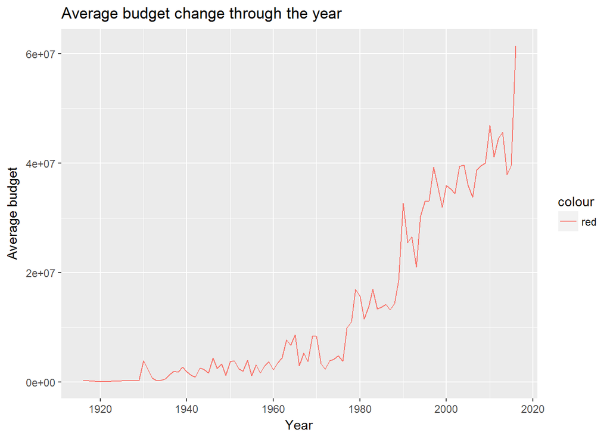

```r
ggplot(BG,aes(x=`Year`,y=`Average budget`))+geom_line(aes(color="red"))+ ggtitle("Average budget change through the year")
```

## 7. IMDB score through the year.

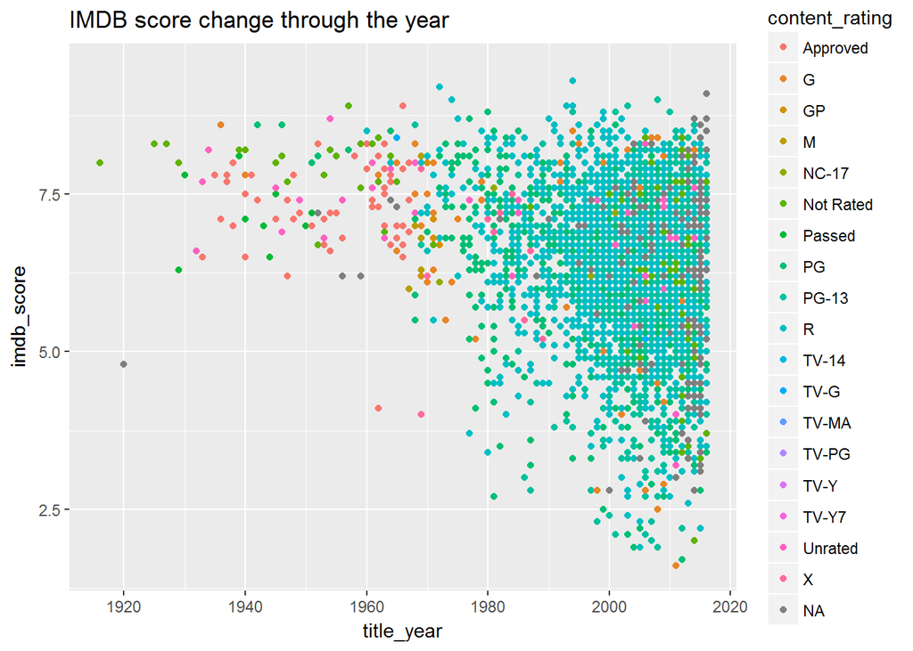

```r
library(ggplot2)
Score_plot=ggplot(movie,aes(x=title_year, y=imdb_score, color=content_rating))+geom_point() + ggtitle("IMDB score change through the year")
Score_plot
```

## IMDB score by content_rating

[figure not shown]

```r
bp1<-ggplot(movie,aes(x=content_rating,y=imdb_score))+geom_boxplot(color="black",fill="green")+ggtitle("IMDB score by content rating")
bp1
```

## 8. Correlation. Choose the quantitatives variables and compute

```r
library(corrplot)
data_cor=data.frame(USUK$budget,USUK$imdb_score, USUK$gross, USUK$actor_2_facebook_likes, USUK$actor_3_facebook_likes, USUK$movie_facebook_likes, USUK$num_voted_users, USUK$num_user_for_reviews, USUK$num_critic_for_reviews, USUK$duration, USUK$actor_1_facebook_likes, USUK$director_facebook_likes, USUK$facenumber_in_poster, USUK$cast_total_facebook_likes)
correlation=cor(data_cor, use="complete")
correlation
```

```
##                                USUK.budget USUK.imdb_score  USUK.gross
## USUK.budget                     1.00000000      0.05123141  0.65543886
## USUK.imdb_score                 0.05123141      1.00000000  0.24815403
## USUK.gross                      0.65543886      0.24815403  1.00000000
## USUK.actor_2_facebook_likes     0.25393980      0.11929225  0.25144655
## USUK.actor_3_facebook_likes     0.27690542      0.07910617  0.30468605
## USUK.movie_facebook_likes       0.32717742      0.28755419  0.37642422
## USUK.num_voted_users            0.40193998      0.49713752  0.63186324
## USUK.num_user_for_reviews       0.41787017      0.34033826  0.55342052
## USUK.num_critic_for_reviews     0.48324338      0.35509060  0.48263380
## USUK.duration                   0.29832963      0.36789983  0.27882668
## USUK.actor_1_facebook_likes     0.16020425      0.10985502  0.13614107
## USUK.director_facebook_likes    0.09863561      0.20451102  0.14101309
## USUK.facenumber_in_poster      -0.02664511     -0.06333432 -0.03335756
## USUK.cast_total_facebook_likes  0.24168087      0.12721439  0.22911078
##                                USUK.actor_2_facebook_likes
## USUK.budget                                     0.25393980
## USUK.imdb_score                                 0.11929225
## USUK.gross                                      0.25144655
## USUK.actor_2_facebook_likes                     1.00000000
## USUK.actor_3_facebook_likes                     0.55051116
## USUK.movie_facebook_likes                       0.23655725
## USUK.num_voted_users                            0.24877009
## USUK.num_user_for_reviews                       0.19735612
## USUK.num_critic_for_reviews                     0.26487400
## USUK.duration                                   0.14586027
## USUK.actor_1_facebook_likes                     0.38505410
## USUK.director_facebook_likes                    0.11884055
## USUK.facenumber_in_poster                       0.07149464
## USUK.cast_total_facebook_likes                  0.63773138
##                                USUK.actor_3_facebook_likes
## USUK.budget                                     0.27690542
## USUK.imdb_score                                 0.07910617
## USUK.gross                                      0.30468605
## USUK.actor_2_facebook_likes                     0.55051116
## USUK.actor_3_facebook_likes                     1.00000000
## USUK.movie_facebook_likes                       0.28171072
## USUK.num_voted_users                            0.27546416
## USUK.num_user_for_reviews                       0.21989805
## USUK.num_critic_for_reviews                     0.26687740
```

[output cut: 110 more lines]

```
##                                USUK.cast_total_facebook_likes
## USUK.budget                                        0.24168087
## USUK.imdb_score                                    0.12721439
## USUK.gross                                         0.22911078
## USUK.actor_2_facebook_likes                        0.63773138
## USUK.actor_3_facebook_likes                        0.48740393
## USUK.movie_facebook_likes                          0.20521910
## USUK.num_voted_users                               0.24774363
## USUK.num_user_for_reviews                          0.18441377
## USUK.num_critic_for_reviews                        0.24389686
## USUK.duration                                      0.13425153
## USUK.actor_1_facebook_likes                        0.94481796
## USUK.director_facebook_likes                       0.11860837
## USUK.facenumber_in_poster                          0.08465145
## USUK.cast_total_facebook_likes                     1.00000000
```

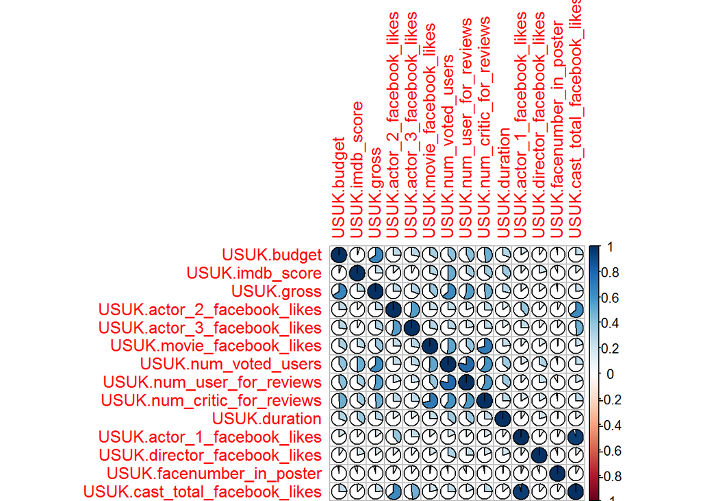

```r
corrplot(correlation, method="pie")
```

## Correlation between Profit and budget

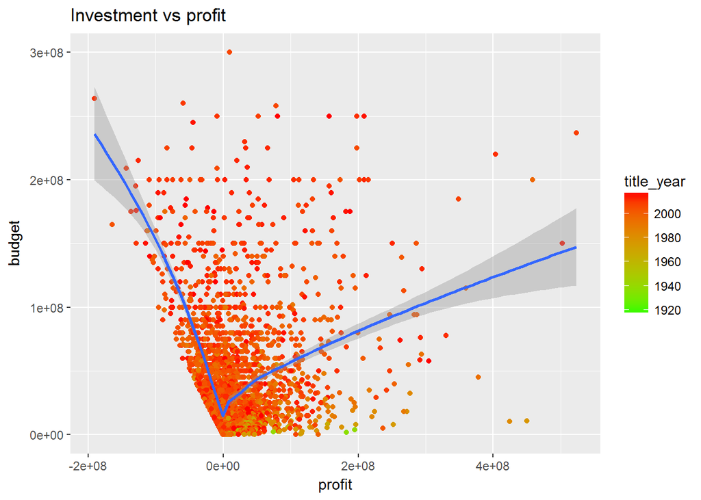

```r
USUK$profit = USUK$gross - USUK$budget
 ggplot(USUK, aes(x=profit, y=budget, color=title_year))+geom_point()+geom_smooth()+scale_colour_gradient(low = "green",high="red")+ggtitle("Investment vs profit")
```

##II PCA AND CLUSTER ANALYSIS ## PCA We try to find a lower dimensional represenation of quantitative variable in the dataset Choose the quantitative variable in the dataset. We omit some variable relate to single cast facebook like and choose 2 variables represent for social popularity of the movie, which is cast total facebook like and movie facebook like. Finally we have 7 variables to perform PCA. Another notation is that the quantitative variables relate to money, so we subset from USUK data only to avoid difference in currency. Scale option is True because data of different nature

```r
movie.number=na.omit(USUK[,list(movie_title,num_critic_for_reviews,gross, num_voted_users, cast_total_facebook_likes,budget,imdb_score, movie_facebook_likes)])
```

```r
pr.out=prcomp(movie.number[,2:8], scale=TRUE)
pr.out
```

```
## Standard deviations:
## [1] 1.8443283 1.0325699 0.9341692 0.8697646 0.6317551 0.5246453 0.4782499
##
## Rotation:
##                                  PC1         PC2         PC3         PC4
## num_critic_for_reviews    -0.4517082  0.09335804 -0.10078769  0.40137673
## gross                     -0.4220145 -0.30514418 -0.17708361 -0.40530002
## num_voted_users           -0.4514955  0.18729459 -0.03998247 -0.23680206
## cast_total_facebook_likes -0.2173803 -0.22020030  0.94811538  0.05713474
## budget                    -0.3651515 -0.56587045 -0.17656242 -0.13940858
## imdb_score                -0.2711951  0.67951304  0.13147715 -0.43841989
## movie_facebook_likes      -0.3998483  0.18071121 -0.09747484  0.63532847
##                                  PC5         PC6          PC7
## num_critic_for_reviews    -0.2478509  0.55939598 -0.491557290
## gross                      0.2915994 -0.38374473 -0.548519704
## num_voted_users            0.5758147  0.41477511  0.446987388
## cast_total_facebook_likes  0.0281621 -0.02153916 -0.028521030
## budget                    -0.5400624  0.02496968  0.451170750
## imdb_score                -0.4649949 -0.19745211  0.003075408
## movie_facebook_likes       0.1153098 -0.57245347  0.230915323
```

## We try to define the Variance explained by these 7 PC, by computing the PVE and chart them

```r
variance=pr.out$sdev^2
pve=variance/sum(variance)
cumsum(pve)
```

```
## [1] 0.4859353 0.6382496 0.7629171 0.8709871 0.9280035 0.9673253 1.0000000
```

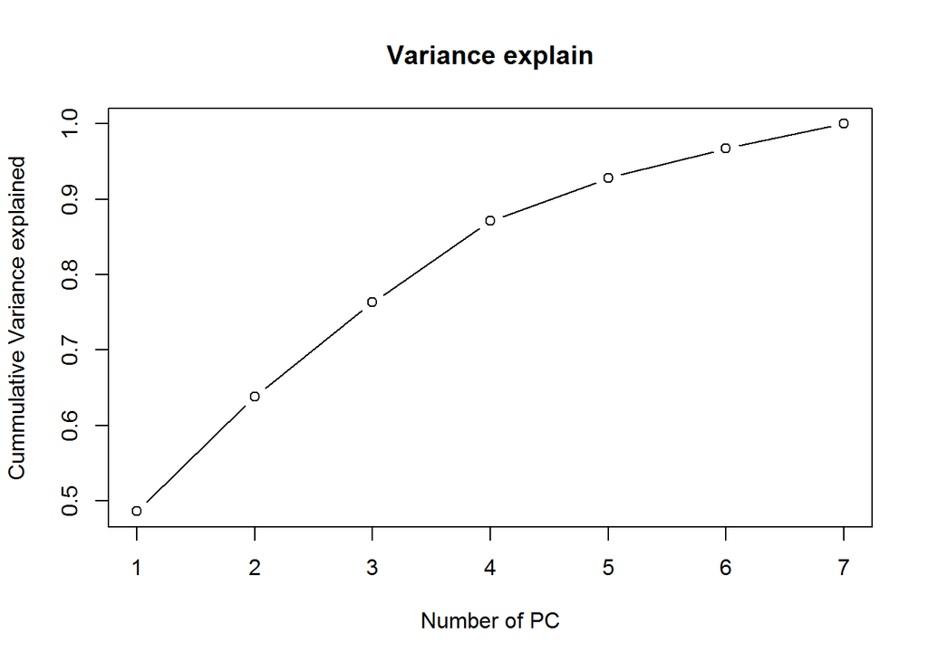

```r
plot(cumsum(pve), type="b", xlab="Number of PC", ylab="Cummulative Variance explained", main="Variance explain")
```

## The dimension doesnt reduce drammatically , at least 5 first PC explain more than 90% of the whole data = > All variable are quite important and bring different information ## Try the biplot of the PC1 and 2

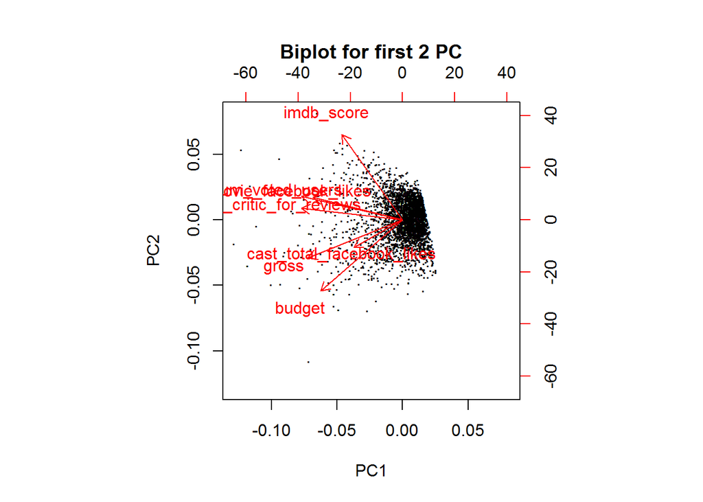

```r
biplot(pr.out, xlabs=rep(".", nrow(movie.number[,2:8])), main = "Biplot for first 2 PC")
```

## Customize the biplot. Look at the variables imdb_score and Budget

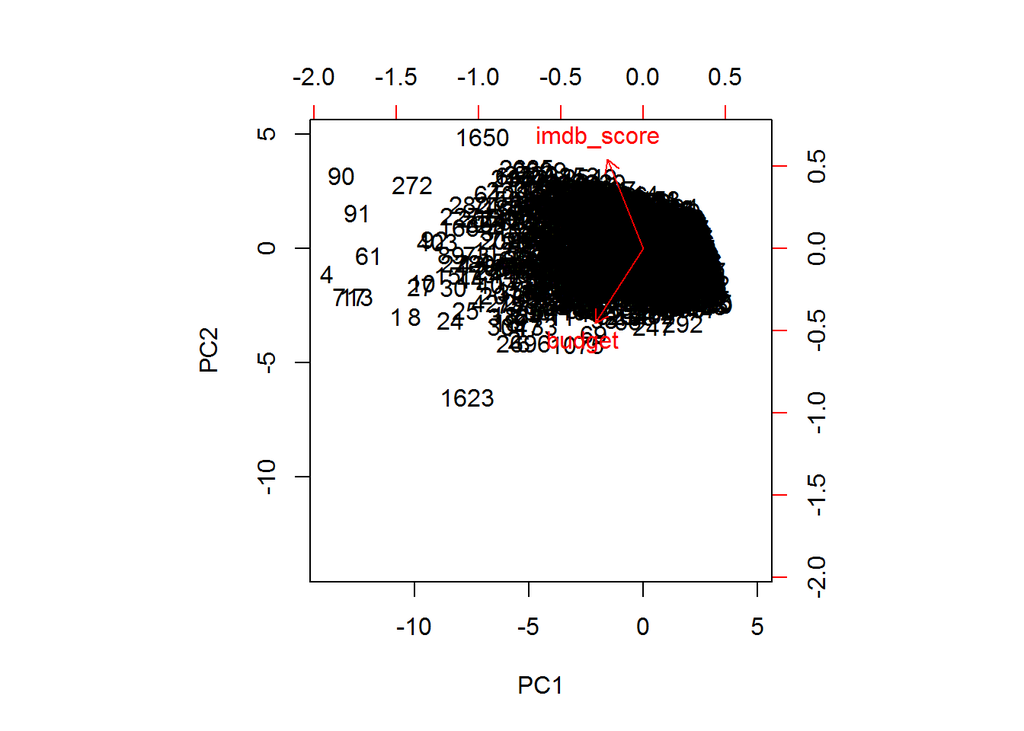

```r
biplot(pr.out$x,pr.out$rotation[c(5,6),])
```

Call out some items that have distinct Score

```r
movie.number[c(1650,272, 10,27,8,24,25,1623,90),list(movie_title, budget, imdb_score, gross)]
```

```
##                                movie_title   budget imdb_score     gross
## 1:              The Shawshank RedemptionÂ  2.50e+07        9.3  28341469
## 2:                      Django UnchainedÂ  1.00e+08        8.5 162804648
## 3:    Batman v Superman: Dawn of JusticeÂ  2.50e+08        6.9 330249062
## 4:                        Jurassic WorldÂ  1.50e+08        7.0 652177271
## 5:               Avengers: Age of UltronÂ  2.50e+08        7.5 458991599
## 6:                               TitanicÂ  2.00e+08        7.7 658672302
## 7:            Captain America: Civil WarÂ  2.50e+08        8.2 407197282
## 8: Anchorman: The Legend of Ron BurgundyÂ  2.60e+07        7.2  84136909
## 9:                          InterstellarÂ  1.65e+08        8.6 187991439
```

## Analyse: The direction of arrow, and soome clear item like 1650.272.10….Try to plot the first 2 PC on the 2d plot to see if any cluster can be seen

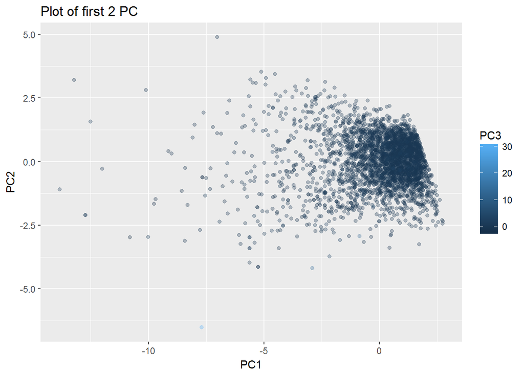

```r
Pc= as.data.frame(pr.out$x)
ggplot(Pc,aes(x=PC1,y=PC2))+geom_point(aes(color=PC3),alpha=0.3)+ggtitle("Plot of first 2 PC")
```

## No distinct group can be seen from this. Try to give some information from the loading factors and scores.

## Identify how many cluster we should use:

## Scale the data

```r
movie.number.scale=scale(movie.number[,2:8])
```

## Check the totwithinss rate

```r
ratiowss=vector()
for (i in 2:10){km=kmeans(movie.number.scale,i,iter.max=30,nstart=50)
ratiowss[i]=km$tot.withinss/km$totss}
```

## Plot the result

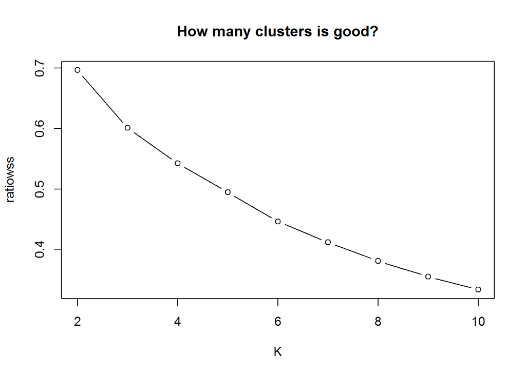

```r
dt<-data.table("K"=2:10, "ratiowss"=ratiowss[2:10])
plot(dt, type="b",  main="How many clusters is good?")
```

```r
dt
```

```
##     K  ratiowss
## 1:  2 0.6967886
## 2:  3 0.6010934
## 3:  4 0.5422224
## 4:  5 0.4946707
## 5:  6 0.4462012
## 6:  7 0.4118536
## 7:  8 0.3809383
## 8:  9 0.3552019
## 9: 10 0.3335161
```

## The result doesnt indicate good result. Try with h-clust to see how many cluster should be used?

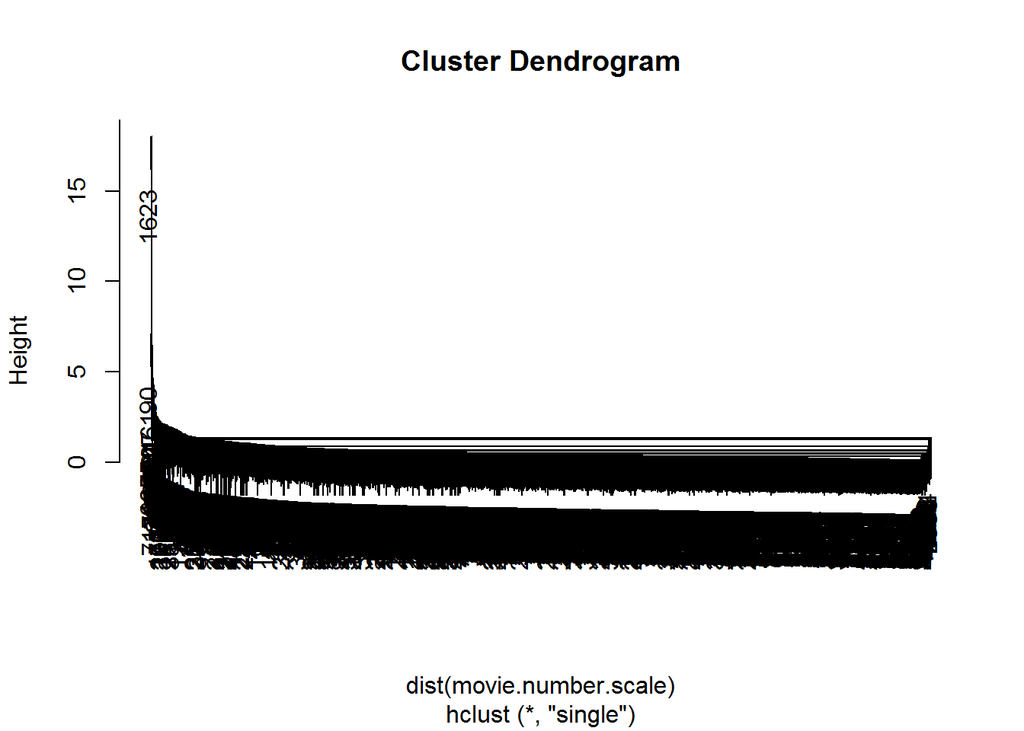

```r
hclust.s=hclust(dist(movie.number.scale), method="single")
plot(hclust.s)
```

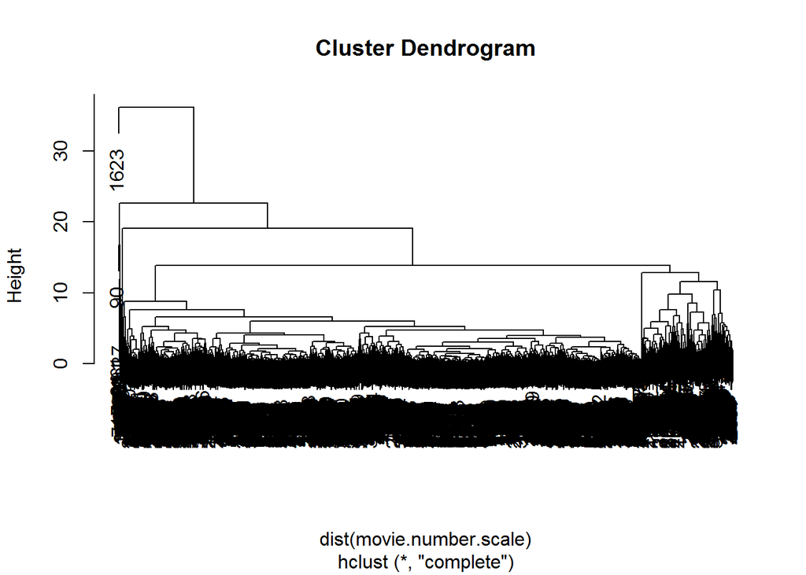

```r
hclust.c=hclust(dist(movie.number.scale), method="complete")
plot(hclust.c)
```

```r
hclust.a=hclust(dist(movie.number.scale), method="average")
```

## Plot the dendrogram

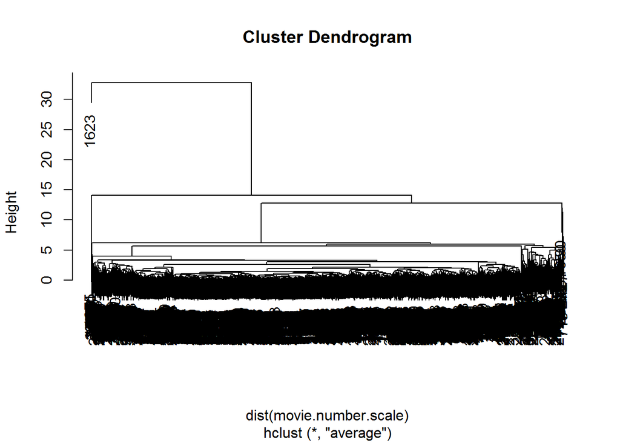

```r
plot(hclust.a)
```

## We will go deeper into average method which produce a quite nice tree ## Convert hclust object into dendrogram object

```r
hclust.a1=as.dendrogram(hclust.a)
```

## Cut the tree at a specific height for easy interpretation

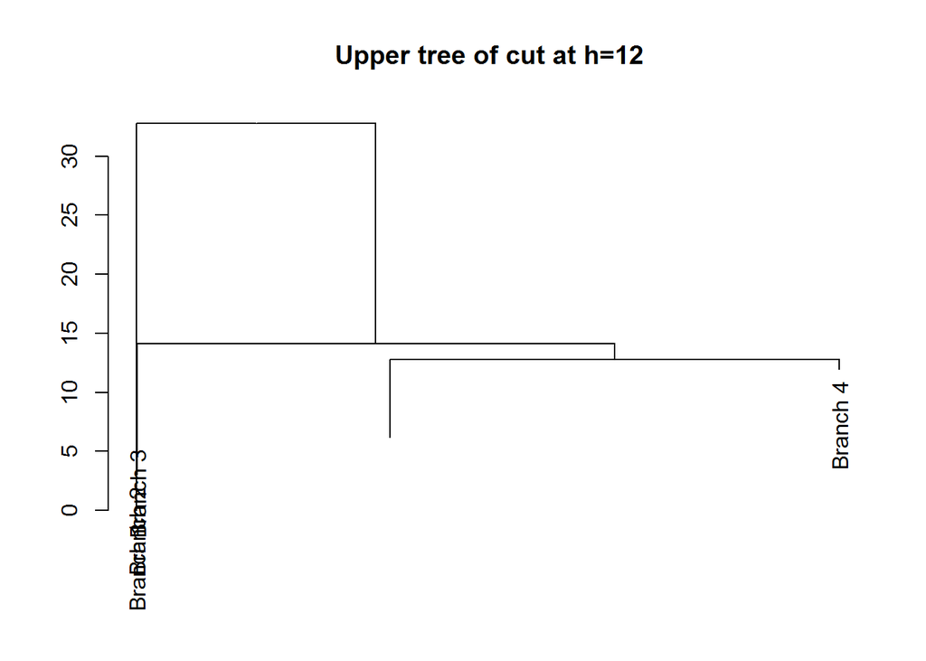

```r
plot(cut(hclust.a1, h = 12)$upper, main = "Upper tree of cut at h=12")
```

## From above result, 5 clusters will be a compromising choice to see ## Lets use the 5 clusters from h clust

```r
h.clust.5=cutree(hclust.a,k=5)
table(h.clust.5)
```

```
## h.clust.5
##    1    2    3    4    5
##   13 3381    1    2    1
```

## Compute k=5 by K-means

```r
km=kmeans(movie.number.scale,5,iter.max=30,nstart=50)
km
```

```
## K-means clustering with 5 clusters of sizes 154, 421, 1500, 435, 888
##
## Cluster means:
##   num_critic_for_reviews       gross num_voted_users
## 1              2.2731809  2.86249222       2.7375573
## 2              1.2529395  0.03975666       0.8442129
## 3             -0.3618577 -0.35948107      -0.3338465
## 4              0.4088625  0.96132325       0.4037828
## 5             -0.5772816 -0.37895874      -0.5088663
##   cast_total_facebook_likes     budget imdb_score movie_facebook_likes
## 1                 1.2126173  2.2638621  1.0789631           2.43480333
## 2                 0.2091532 -0.1976046  0.8212454           1.08836563
## 3                -0.1551576 -0.4398127  0.3658637          -0.32460674
## 4                 0.4219945  1.3671666  0.0893137          -0.05702193
## 5                -0.2540853 -0.2257226 -1.2382338          -0.36198985
```

[output cut: 112 more lines]

```r
table(km$cluster,h.clust.5)
```

```
##    h.clust.5
##        1    2    3    4    5
##   1   13  139    1    0    1
##   2    0  421    0    0    0
##   3    0 1500    0    0    0
##   4    0  433    0    2    0
##   5    0  888    0    0    0
```

The result of h-clust and k-clust are very different. K cluster: From the mean of variables can intepret something? H-cluster: There is 1 very big group and other small group. There may be no clear grouping available using this method However, the observation 1623 and 90 is something different Call out the item 1623 and 90 for analysis

```r
movie.number[c(1623,90),]
```

```
##                                movie_title num_critic_for_reviews
## 1: Anchorman: The Legend of Ron BurgundyÂ                     181
## 2:                          InterstellarÂ                     712
##        gross num_voted_users cast_total_facebook_likes   budget imdb_score
## 1:  84136909          267921                    656730 2.60e+07        7.2
## 2: 187991439          928227                     31488 1.65e+08        8.6
##    movie_facebook_likes
## 1:                    0
## 2:               349000
```

Comput the summary of movie.number to compare if any thing can be seen

```r
summary(movie.number)
```

```
##                       movie_title   num_critic_for_reviews
##  HalloweenÂ                 :   3   Min.   :  1
##  HomeÂ                      :   3   1st Qu.: 74
##  PanÂ                       :   3   Median :135
##  The Fast and the FuriousÂ  :   3   Mean   :165
##  Victor FrankensteinÂ       :   3   3rd Qu.:223
##  A Nightmare on Elm StreetÂ :   2   Max.   :813
##  (Other)                    :3381
##      gross           num_voted_users   cast_total_facebook_likes
##  Min.   :      703   Min.   :      5   Min.   :     0
##  1st Qu.: 10222635   1st Qu.:  18701   1st Qu.:  2054
##  Median : 32131656   Median :  54060   Median :  4292
##  Mean   : 55239290   Mean   : 106945   Mean   : 11953
##  3rd Qu.: 70783718   3rd Qu.: 130088   3rd Qu.: 16603
##  Max.   :760505847   Max.   :1689764   Max.   :656730
##
##      budget            imdb_score    movie_facebook_likes
##  Min.   :      218   Min.   :1.600   Min.   :     0
##  1st Qu.: 10000000   1st Qu.:5.800   1st Qu.:     0
##  Median : 25000000   Median :6.500   Median :   238
##  Mean   : 39168763   Mean   :6.431   Mean   :  9414
##  3rd Qu.: 50175000   3rd Qu.:7.175   3rd Qu.: 11000
##  Max.   :300000000   Max.   :9.300   Max.   :349000
##
```

Also observation from K-cluster that first group is quite different, all the mean are far higher. Let’s try to analyse the first group

```r
movie.number$group=km$cluster
k.group1=movie.number[group==1]
summary(k.group1)
```

```
##                       movie_title  num_critic_for_reviews
##  Alice in WonderlandÂ       :  2   Min.   :149.0
##  Oz the Great and PowerfulÂ :  2   1st Qu.:325.0
##  SkyfallÂ                   :  2   Median :451.0
##  Spider-Man 3Â              :  2   Mean   :450.6
##  The AvengersÂ              :  2   3rd Qu.:538.8
##  The Jungle BookÂ           :  2   Max.   :813.0
##  (Other)                    :142
##      gross           num_voted_users   cast_total_facebook_likes
##  Min.   : 28341469   Min.   : 106072   Min.   :    87
##  1st Qu.:172051787   1st Qu.: 314785   1st Qu.: 13136
##  Median :248464891   Median : 466316   Median : 24047
##  Mean   :261056084   Mean   : 531546   Mean   : 35925
##  3rd Qu.:335568472   3rd Qu.: 660268   3rd Qu.: 48309
##  Max.   :760505847   Max.   :1689764   Max.   :656730
##
##      budget           imdb_score    movie_facebook_likes     group
##  Min.   :6.00e+06   Min.   :5.500   Min.   :     0       Min.   :1
##  1st Qu.:8.00e+07   1st Qu.:7.000   1st Qu.: 24000       1st Qu.:1
##  Median :1.50e+08   Median :7.600   Median : 52500       Median :1
##  Mean   :1.38e+08   Mean   :7.563   Mean   : 62312       Mean   :1
##  3rd Qu.:1.90e+08   3rd Qu.:8.100   3rd Qu.: 83000       3rd Qu.:1
##  Max.   :3.00e+08   Max.   :9.300   Max.   :349000       Max.   :1
##
```

Comment on this group ## TREE Buil a classification tree for imdb score Because the variable budget and gross will also be used in this prediction, the data used here will be USUK only with the same currency difference reason Before compute the tree, we do some data cleaning. Variable relate to actor name, movie title, director name, plot keyword, website link will be omitted, either because they doesnt give input for prediction or their levels are too many which can not be executed in R. Variable language are transformed into LangEng holds 2 value TRUE or FALSE Because Random forest doesnt handle the NA value, so we remove all NA from now to run all the tree, bagging and random forest, because later on, if the number of observation between trees and random forest are not equal, then it wont be equal to compare the misclassification rate.

```r
USUK$langEng=USUK$language=="English"
USUK$country <- factor(USUK$country)
USUK$qualityrating=cut(USUK$imdb_score, breaks=c(0,5,6.5,8,10), include.lowest = TRUE, labels=c("Bad","Average","Good","Great"))
USUK.datatree=na.omit(USUK[, list(color, num_critic_for_reviews, duration, director_facebook_likes, actor_3_facebook_likes, actor_1_facebook_likes,gross, num_voted_users, cast_total_facebook_likes,facenumber_in_poster, num_user_for_reviews, langEng, country, content_rating,budget, title_year, actor_2_facebook_likes, qualityrating, aspect_ratio, movie_facebook_likes)])
```

Divide the data into 1000 for test set and balance for training set

```r
library(tree)
set.seed(1)
test=sample(nrow(USUK.datatree), 1000)
movie.train=USUK.datatree[-test,]
movie.test=USUK.datatree[test,]
```

```r
r1.tree=tree(qualityrating~.,movie.train)
r1.tree
```

```
## node), split, n, deviance, yval, (yprob)
##       * denotes terminal node
##
##  1) root 2314 4933.00 Good ( 0.089455 0.423509 0.448142 0.038894 )
##    2) num_voted_users < 172922 1877 3662.00 Average ( 0.108684 0.491209 0.396910 0.003197 )
##      4) duration < 110.5 1252 2472.00 Average ( 0.144569 0.538339 0.315495 0.001597 )
##        8) budget < 1.375e+007 509  993.20 Good ( 0.104126 0.416503 0.475442 0.003929 )
##         16) num_voted_users < 58371.5 403  804.70 Average ( 0.129032 0.481390 0.387097 0.002481 ) *
##         17) num_voted_users > 58371.5 106  118.40 Good ( 0.009434 0.169811 0.811321 0.009434 ) *
##        9) budget > 1.375e+007 743 1373.00 Average ( 0.172275 0.621803 0.205922 0.000000 )
##         18) num_voted_users < 53874 424  787.90 Average ( 0.266509 0.599057 0.134434 0.000000 ) *
##         19) num_voted_users > 53874 319  500.20 Average ( 0.047022 0.652038 0.300940 0.000000 ) *
##      5) duration > 110.5 625 1057.00 Good ( 0.036800 0.396800 0.560000 0.006400 )
##       10) budget < 3.55e+007 361  549.10 Good ( 0.033241 0.254848 0.700831 0.011080 ) *
##       11) budget > 3.55e+007 264  428.30 Average ( 0.041667 0.590909 0.367424 0.000000 ) *
##    3) num_voted_users > 172922 437  776.70 Good ( 0.006865 0.132723 0.668192 0.192220 )
##      6) num_voted_users < 559631 382  576.40 Good ( 0.007853 0.151832 0.751309 0.089005 )
##       12) budget < 4.95e+007 168  190.80 Good ( 0.000000 0.023810 0.803571 0.172619 ) *
##       13) budget > 4.95e+007 214  315.90 Good ( 0.014019 0.252336 0.710280 0.023364 ) *
##      7) num_voted_users > 559631 55   33.51 Great ( 0.000000 0.000000 0.090909 0.909091 ) *
```

```r
summary(r1.tree)
```

```
##
## Classification tree:
## tree(formula = qualityrating ~ ., data = movie.train)
## Variables actually used in tree construction:
## [1] "num_voted_users" "duration"        "budget"
## Number of terminal nodes:  9
## Residual mean deviance:  1.618 = 3729 / 2305
## Misclassification error rate: 0.357 = 826 / 2314
```

Plot the tree

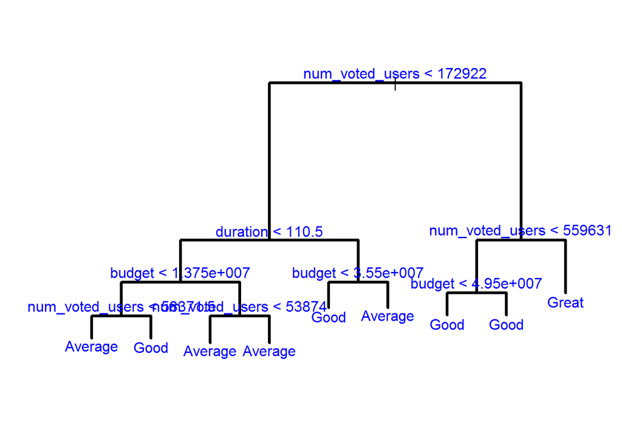

```r
plot(r1.tree,lwd=3)
text(r1.tree,pretty=0,cex=1,col="blue")
```

Check with the test set

```r
r1.tree.predict=predict(r1.tree, movie.test,type="class")

qualityrating.test=USUK.datatree$qualityrating[test]

table(r1.tree.predict, qualityrating.test)
```

```
##                qualityrating.test
## r1.tree.predict Bad Average Good Great
##         Bad       0       0    0     0
##         Average  84     329  194     2
##         Good      8      64  279    18
##         Great     0       0    3    19
```

```r
(84+194+2+8+64+18+3)/nrow(movie.test)
```

```
## [1] 0.373
```

[1] 0.373 Grow a bigger tree

```r
setup1=tree.control(nrow(USUK.datatree),mincut =5,minsize =10,mindev =0.001)
r2.tree=tree(qualityrating~.,data=movie.train,control=setup1)
summary(r2.tree)
```

```
##
## Classification tree:
## tree(formula = qualityrating ~ ., data = movie.train, control = setup1)
## Variables actually used in tree construction:
##  [1] "num_voted_users"           "duration"
##  [3] "budget"                    "country"
##  [5] "actor_1_facebook_likes"    "actor_3_facebook_likes"
##  [7] "gross"                     "actor_2_facebook_likes"
##  [9] "num_user_for_reviews"      "movie_facebook_likes"
## [11] "title_year"                "num_critic_for_reviews"
## [13] "facenumber_in_poster"      "director_facebook_likes"
## [15] "cast_total_facebook_likes" "content_rating"
## [17] "aspect_ratio"
## Number of terminal nodes:  223
## Residual mean deviance:  0.6876 = 1438 / 2091
## Misclassification error rate: 0.1538 = 356 / 2314
```

Plot the r2.tree

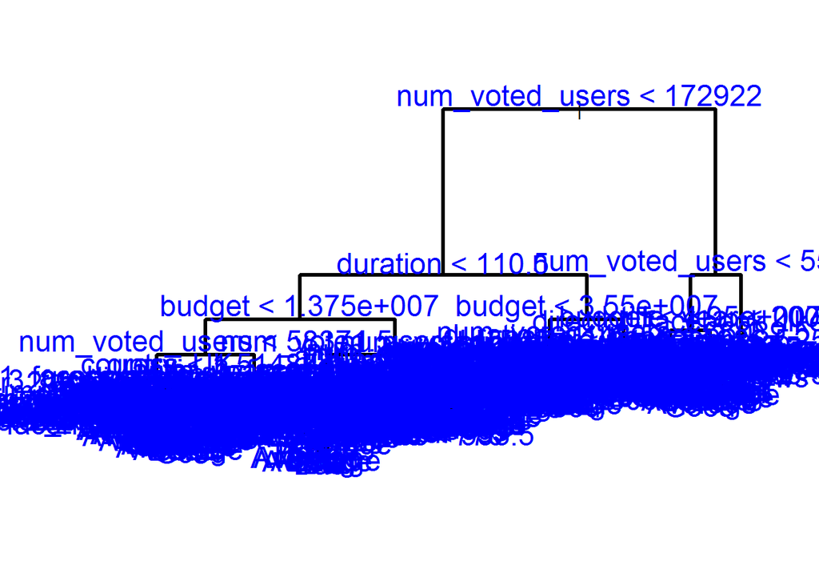

```r
plot(r2.tree,lwd=3)
text(r2.tree,pretty=0,cex=1.5,col="blue")
```

Predict on test set the big tree

```r
r2.tree.predict=predict(r2.tree, movie.test,type="class")
table(r2.tree.predict, qualityrating.test)
```

```
##                qualityrating.test
## r2.tree.predict Bad Average Good Great
##         Bad      31      55   13     0
##         Average  41     224  117     0
##         Good     20     114  341    15
##         Great     0       0    5    24
```

```r
(55+13+41+117+20+114+15+5)/nrow(movie.test)
```

```
## [1] 0.38
```

[1] 0.38 WOrse Cross validation for the tree to choose the best number of nod

```r
set.seed (2)
cv.movie =cv.tree(r2.tree ,FUN=prune.misclass )
cv.movie
```

```
## $size
##  [1] 223 179 175 173 170 151 144 132 114 109  95  90  80  75  66  62  56
## [18]  47  30  24  22  14  13  11  10   8   7   5   4   3   2   1
##
## $dev
##  [1]  903  903  903  903  903  903  903  906  906  906  906  906  906  906
## [15]  906  906  906  906  906  906  906  906  906  906  899  890  888  925
## [29]  961 1045 1100 1229
##
## $k
##  [1]        -Inf   0.0000000   0.2500000   0.5000000   0.6666667
##  [6]   1.0000000   1.2857143   1.5000000   1.6666667   1.8000000
## [11]   2.0000000   2.2000000   2.5000000   2.6000000   3.0000000
## [16]   3.2500000   3.5000000   3.5555556   3.5882353   4.0000000
## [21]   5.0000000   5.7500000   6.0000000   6.5000000   8.0000000
## [26]  11.0000000  21.0000000  34.0000000  45.0000000  59.0000000
## [31] 102.0000000 177.0000000
##
## $method
## [1] "misclass"
##
## attr(,"class")
## [1] "prune"         "tree.sequence"
```

Plot the result

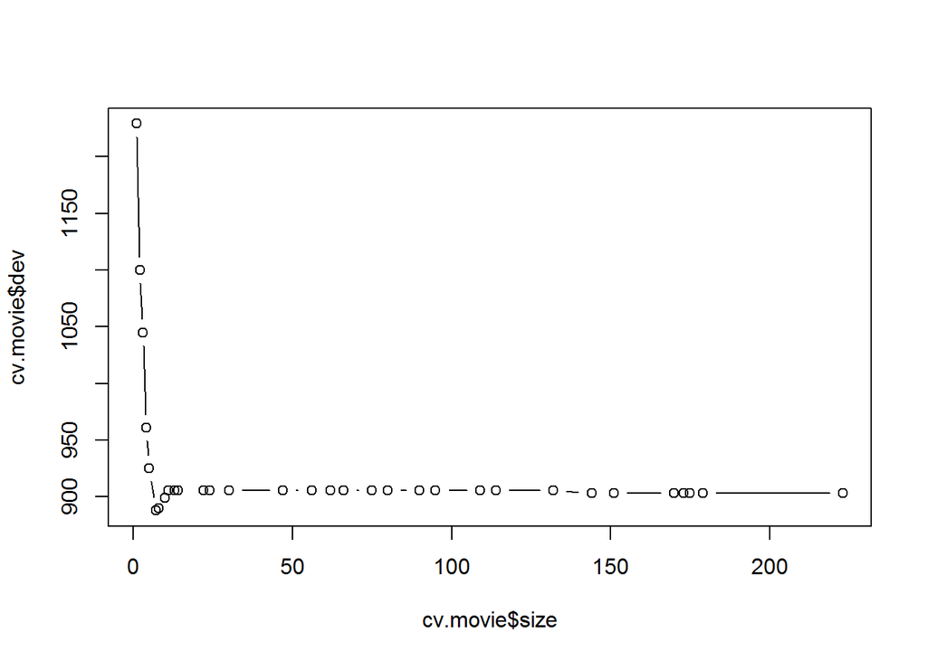

```r
plot(cv.movie$size, cv.movie$dev, type="b")
```

From the CV result, we see that tree with 11 nods is as good as tree with 132 nods. so we gonna prune the tree with 11 nods

```r
prune.r2.tree=prune.misclass(r2.tree,best =11)
```

Plot it

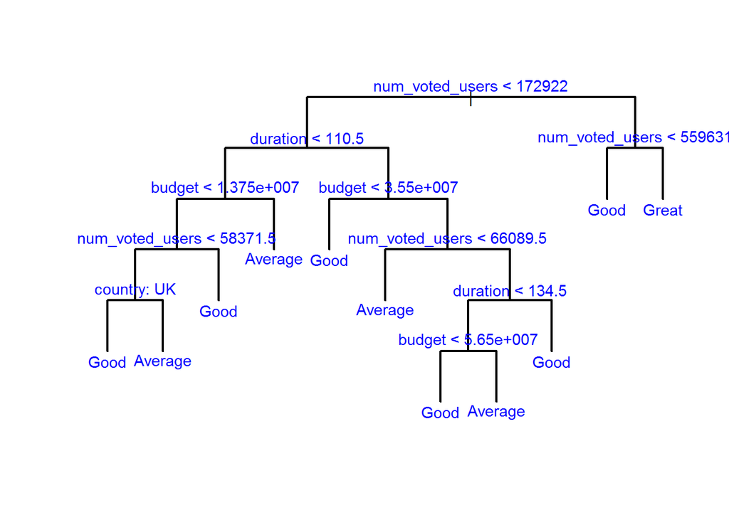

```r
plot(prune.r2.tree,type="uniform",lwd=2)
text(prune.r2.tree ,pretty =0,cex=0.9,col="blue")
```

Again predict this tree on test set

```r
prune.r2.tree.predict=predict(prune.r2.tree, movie.test,type="class")
table(prune.r2.tree.predict, qualityrating.test)
```

```
##                      qualityrating.test
## prune.r2.tree.predict Bad Average Good Great
##               Bad       0       0    0     0
##               Average  83     308  156     1
##               Good      9      85  317    19
##               Great     0       0    3    19
```

```r
(83+156+1+9+85+19+3)/nrow(movie.test)
```

```
## [1] 0.356
```

[1] 0.356 Improvement!!! ## Bagging

```r
library (randomForest)
set.seed (3)
bag.movie=randomForest(qualityrating~.,movie.train,mtry=19,importance =TRUE,ntree=500)
bag.movie
```

```
##
## Call:
##  randomForest(formula = qualityrating ~ ., data = movie.train,      mtry = 19, importance = TRUE, ntree = 500)
##                Type of random forest: classification
##                      Number of trees: 500
## No. of variables tried at each split: 19
##
##         OOB estimate of  error rate: 30.55%
## Confusion matrix:
##         Bad Average Good Great class.error
## Bad      39     146   22     0   0.8115942
## Average  16     727  237     0   0.2581633
## Good      1     244  779    13   0.2487946
## Great     0       0   28    62   0.3111111
```

Compare with the test set

```r
bag.pred=predict(bag.movie, movie.test,type="class")
table(bag.pred, qualityrating.test)
```

```
##          qualityrating.test
## bag.pred  Bad Average Good Great
##   Bad      21      10    0     0
##   Average  61     291  112     0
##   Good     10      92  361    13
##   Great     0       0    3    26
```

```r
(10+61+112+10+92+13+3)/nrow(movie.test)
```

```
## [1] 0.301
```

[1] 0.301 even better RAndom forest

```r
random.forest=randomForest(qualityrating~.,movie.train,mtry=4,importance =TRUE,ntree=500)
random.forest
```

```
##
## Call:
##  randomForest(formula = qualityrating ~ ., data = movie.train,      mtry = 4, importance = TRUE, ntree = 500)
##                Type of random forest: classification
##                      Number of trees: 500
## No. of variables tried at each split: 4
##
##         OOB estimate of  error rate: 30.21%
## Confusion matrix:
##         Bad Average Good Great class.error
## Bad      24     165   18     0   0.8840580
## Average   6     736  238     0   0.2489796
## Good      0     228  803     6   0.2256509
## Great     0       0   38    52   0.4222222
```

Predict with test set

```r
rf.pred=predict(random.forest, movie.test,type="class")
table(rf.pred, qualityrating.test)
```

```
##          qualityrating.test
## rf.pred   Bad Average Good Great
##   Bad       7       4    0     0
##   Average  71     291  101     0
##   Good     14      98  371    18
##   Great     0       0    4    21
```

```r
(4+71+101+14+98+18+4)/nrow(movie.test)
```

```
## [1] 0.31
```

REsult [1] 0.31 Not as good as bagging Try to see the importance of variables in splitting.

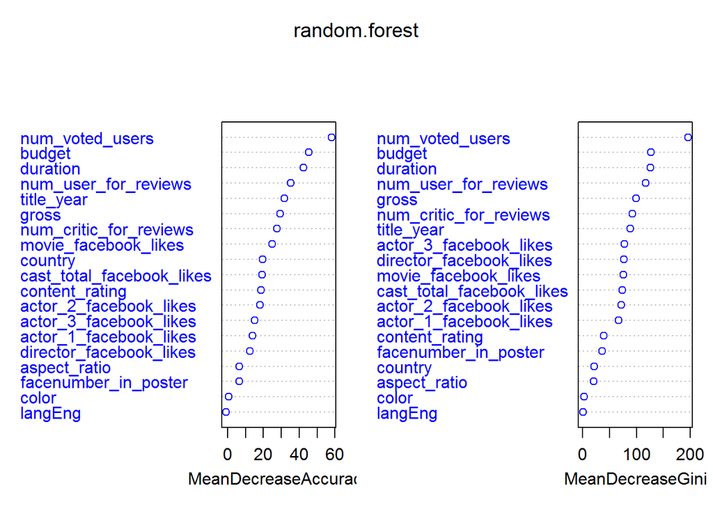

```r
varImpPlot(random.forest, col="blue", lwd=5)
```